# Exercicio 4 - Machine Learning - Redes Neurais

Amanda Provetti

Contexto do problema: Temos o objetivo de construir um modelo preditivo de ML baseado em Redes Neurais Artificiais (RNAs) que seja capaz de realizar predições dos valores medianos de preços das casas em uma região suburbana de Boston, EUA. Tal como no caso da regressão linear, a variável a ser predita consiste em um valor numérico que representa o preço mediano das casas. Para cada uma das observações, temos diversas variáveis de entrada. Logo, podemos buscar a solução para esse problema usando diferentes técnicas de Machine Learning: nesse caso iremos construir, treinar e testar uma rede neural artificial para fazer as predições. O pacote neuralnet pode ser usado para construirmos o modelo de RNA. Na linguagem R podemos usar: install.packages(“neuralnet”) library(neuralnet) Dataset: Os dados estão fornecidos na forma de tabela (.xlsx e .csv) retratado pelo dataset Boston, presente na biblioteca MASS do software R que apresenta os valores das casas (Median value of owner-occupied homes) em 506 vizinhanças da cidade de Boston. Os dados que acompanham o valor mediano dos preços das casas consistem em indicadores de condições socioeconômicas, ambientais, instalações educacionais e alguns outros fatores semelhantes. No ambiente R, o comando ?Boston fornece informações sobre cada uma das features.

Ao todo, são 13 features e uma variável resposta, denotada como medv (preço mediano da casa), baseada em $1,000 dólares. De forma específica, no conjunto de variáveis explanatórias (i.e., características), temos doze (12) variáveis numéricas e uma (1) variável categórica, que no caso pode assumir 0 (zero) ou 1 (um). Com isso, a planilha de dados apresenta 506 linhas (exemplos de treinamento) e 14 colunas (features). Abaixo, estão colocadas cada uma das variáveis características do dataset e seu respectivo significado: • CRIM: per capita crime rate by town • ZN: proportion of residential land zoned for lots over 25,000 sq.ft. • INDUS: proportion of non-retail business acres per town • CHAS: Charles River dummy variable (= 1 if tract bounds river; 0 otherwise) • NOX: nitric oxides concentration (parts per 10 million) • RM: average number of rooms per dwelling • AGE: proportion of owner-occupied units built prior to 1940 • DIS: weighted distances to five Boston employment centres • RAD: index of accessibility to radial highways • TAX: full-value property-tax rate per 10,000 • PTRATIO: pupil-teacher ratio by town • B: 1000(Bk −0.63) 2 where Bk is the proportion of blacks by town • LSTAT: % lower status of the population • TARGET: Median value of owner-occupied homes in $1000’s Abaixo, seguem os itens que devemos solucionar, visando alcançar o objetivo deste exercício:

```r
install.packages("neuralnet")
```

– 1) Faça a exploração dos dados bem como síntese sobre suas principais variáveis explanatórias

```r
boston_table = read_excel("Boston_Tabela.xlsx")
summary(boston_table)
```

```
      crim                zn             indus            chas              nox               rm
 Min.   : 0.00632   Min.   :  0.00   Min.   : 0.46   Min.   :0.00000   Min.   :0.3850   Min.   :3.561
 1st Qu.: 0.08204   1st Qu.:  0.00   1st Qu.: 5.19   1st Qu.:0.00000   1st Qu.:0.4490   1st Qu.:5.886
 Median : 0.25651   Median :  0.00   Median : 9.69   Median :0.00000   Median :0.5380   Median :6.208
 Mean   : 3.61352   Mean   : 11.36   Mean   :11.14   Mean   :0.06917   Mean   :0.5547   Mean   :6.285
 3rd Qu.: 3.67708   3rd Qu.: 12.50   3rd Qu.:18.10   3rd Qu.:0.00000   3rd Qu.:0.6240   3rd Qu.:6.623
 Max.   :88.97620   Max.   :100.00   Max.   :27.74   Max.   :1.00000   Max.   :0.8710   Max.   :8.780
      age              dis              rad              tax           ptratio          black
 Min.   :  2.90   Min.   : 1.130   Min.   : 1.000   Min.   :187.0   Min.   :12.60   Min.   :  0.32
 1st Qu.: 45.02   1st Qu.: 2.100   1st Qu.: 4.000   1st Qu.:279.0   1st Qu.:17.40   1st Qu.:375.38
 Median : 77.50   Median : 3.207   Median : 5.000   Median :330.0   Median :19.05   Median :391.44
 Mean   : 68.57   Mean   : 3.795   Mean   : 9.549   Mean   :408.2   Mean   :18.46   Mean   :356.67
 3rd Qu.: 94.08   3rd Qu.: 5.188   3rd Qu.:24.000   3rd Qu.:666.0   3rd Qu.:20.20   3rd Qu.:396.23
 Max.   :100.00   Max.   :12.127   Max.   :24.000   Max.   :711.0   Max.   :22.00   Max.   :396.90
     lstat            medv
 Min.   : 1.73   Min.   : 5.00
 1st Qu.: 6.95   1st Qu.:17.02
 Median :11.36   Median :21.20
 Mean   :12.65   Mean   :22.53
 3rd Qu.:16.95   3rd Qu.:25.00
 Max.   :37.97   Max.   :50.00
```

2. Realize o procedimento de normalização mínimo-máximo sobre as características do dataframe

```r
dados = boston_table

maximo <- apply(dados, 2, max)
maximo
```

```
    crim       zn    indus     chas      nox       rm      age      dis      rad      tax  ptratio
 88.9762 100.0000  27.7400   1.0000   0.8710   8.7800 100.0000  12.1265  24.0000 711.0000  22.0000
   black    lstat     medv
396.9000  37.9700  50.0000
```

```r
minimo <- apply(dados, 2, min)
minimo
```

```
     crim        zn     indus      chas       nox        rm       age       dis       rad       tax
  0.00632   0.00000   0.46000   0.00000   0.38500   3.56100   2.90000   1.12960   1.00000 187.00000
  ptratio     black     lstat      medv
 12.60000   0.32000   1.73000   5.00000
```

```r
dados_normalizados <- as.data.frame(scale(dados, center = minimo, scale = maximo - minimo))
str(dados_normalizados)
```

```
'data.frame':   506 obs. of  14 variables:
 $ crim   : num  0 0.000236 0.000236 0.000293 0.000705 ...
 $ zn     : num  0.18 0 0 0 0 0 0.125 0.125 0.125 0.125 ...
 $ indus  : num  0.0678 0.2423 0.2423 0.063 0.063 ...
 $ chas   : num  0 0 0 0 0 0 0 0 0 0 ...
 $ nox    : num  0.315 0.173 0.173 0.15 0.15 ...
 $ rm     : num  0.578 0.548 0.694 0.659 0.687 ...
 $ age    : num  0.642 0.783 0.599 0.442 0.528 ...
 $ dis    : num  0.269 0.349 0.349 0.449 0.449 ...
 $ rad    : num  0 0.0435 0.0435 0.087 0.087 ...
 $ tax    : num  0.208 0.105 0.105 0.0668 0.0668 ...
 $ ptratio: num  0.287 0.553 0.553 0.649 0.649 ...
 $ black  : num  1 1 0.99 0.994 1 ...
 $ lstat  : num  0.0897 0.2045 0.0635 0.0334 0.0993 ...
 $ medv   : num  0.422 0.369 0.66 0.631 0.693 ...
```

3. Para reprodução dos resultados use o set.seed(12).

```r
set.seed(12)
```

4. Realize a divisão do conjunto de treino e teste em 70/30

```r
divisao_dados = sample.split(dados_normalizados$medv, SplitRatio = 0.70)
dados_norm_treinamento = subset(dados_normalizados, divisao_dados == TRUE)
dados_norm_teste       = subset(dados_normalizados, divisao_dados == FALSE)
```

– 5) Construa e treine o modelo preditivo de ML baseado em redes neurais artificiais.

```r
nomes_colunas <- colnames(dados_norm_treinamento)

equation_model <- as.formula(paste ( "medv ~ ", paste(nomes_colunas[!nomes_colunas %in% "medv"], collapse = " + ")))

modelo_RNA = neuralnet(equation_model, data = dados_norm_treinamento, hidden = c(5,3), linear.output = TRUE)
```

6. Visualize a arquitetura da RNA treinada

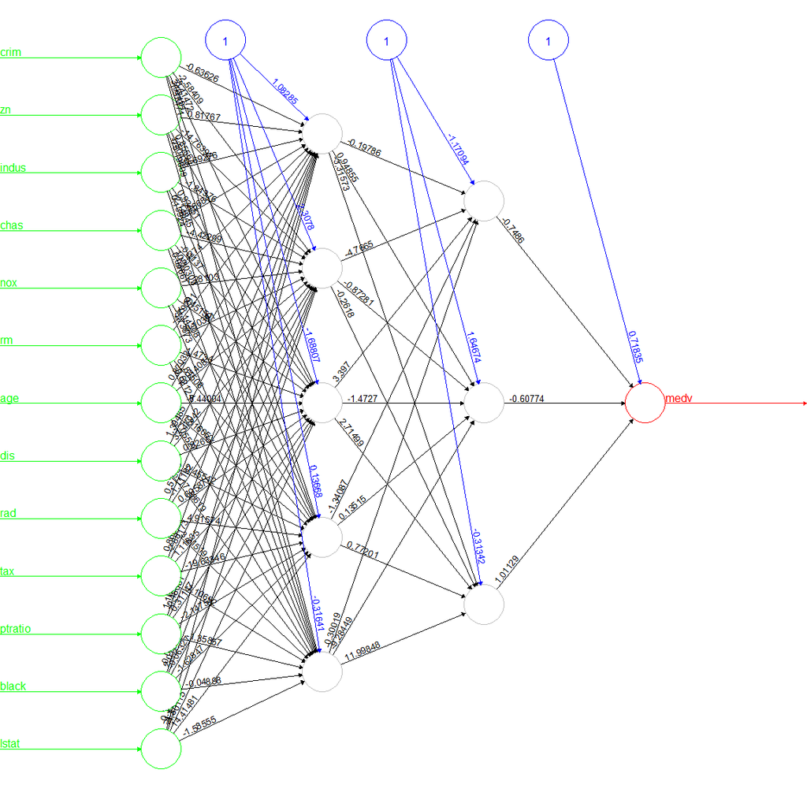

```r
plot(modelo_RNA,col.entry = "green", col.entry.synapse = "green", col.out = "red", col.out.synapse = "red", col.hidden = "gray")
```

7. Aplique o modelo sobre os dados de teste para geração de predições

```r
RNA_pred_norm = compute(modelo_RNA, dados_norm_teste[1:13])
max_medv = max(dados$medv)
min_medv = min(dados$medv)
RNA_pred = RNA_pred_norm$net.result*(max_medv - min_medv) + min_medv
```

8. Forneça a estimativa de erro quadrático médio (MSE)

```r
dados_teste <- (dados_norm_teste$medv)*(max(dados$medv) - min(dados$medv)) + min(dados$medv)

MSE_RNA <- sum(((dados_teste - RNA_pred)^2) )/nrow(RNA_pred)

df_RNA_pred <- data.frame(dados_teste, RNA_pred)
```

[output not shown]

– 9) Compare os resultados de predição com os dados de teste (graficamente)

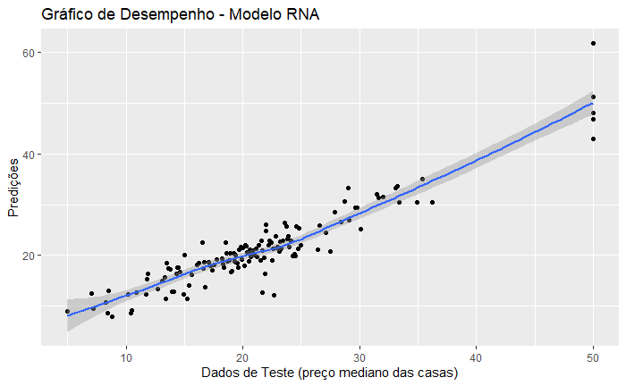

```r
ggplot(df_RNA_pred, aes(x = dados_teste,y = RNA_pred)) +
            geom_point() +
            stat_smooth() +
            xlab('Dados de Teste (preço mediano das casas)') +
            ylab('Predições')  +
            ggtitle("Gráfico de Desempenho - Modelo RNA")
```